# Territory Distributions

Keith Hickman

October 26, 2017

# Intro:

This analysis presents the optimum geographic distribution of territories using Revenue, Number of Accounts, and Types of Account. The data is loaded via three csv files columns `'territorycode'`, `netivcamt`, and `standardized`. territorycode represents the current tagged geo location based on county. netivcamt is the amount of each transaction, with a row or observation representing one transaction (invoice). `standardized` is the normalized value of the netivccolumn.

Begin with loading required packages:

```r
library(ggplot2)
library(DMwR2)
library(data.table)
library(readr)
territorydist <- read_csv("C:/Users/khickman/Desktop/Personal/IUMSDS/AppliedDataMining/territorydist.csv")
```

Summary of our dataset:

```r
summary(territorydist)
```

```
##  territorycode        netivcamt         standardized
##  Length:24587       Min.   :     0.0   Min.   :-0.31817
##  Class :character   1st Qu.:   137.7   1st Qu.:-0.27949
##  Mode  :character   Median :   391.1   Median :-0.20833
##                     Mean   :  1132.9   Mean   : 0.00000
##                     3rd Qu.:  1028.2   3rd Qu.:-0.02938
##                     Max.   :174225.4   Max.   :48.61492
##                     NA's   :1          NA's   :3
```

We have 24584 observations of three variables as mentioned above. There are some obvious outliers as evidence by the Max values of the netivcamt. Additionally, we can tell that the $q3$ (3rd quartile) is represented lower than the mean, which will not be suitable as a statistic of centrality, as it’s sensitive to outliers. We will use median instead going forward.

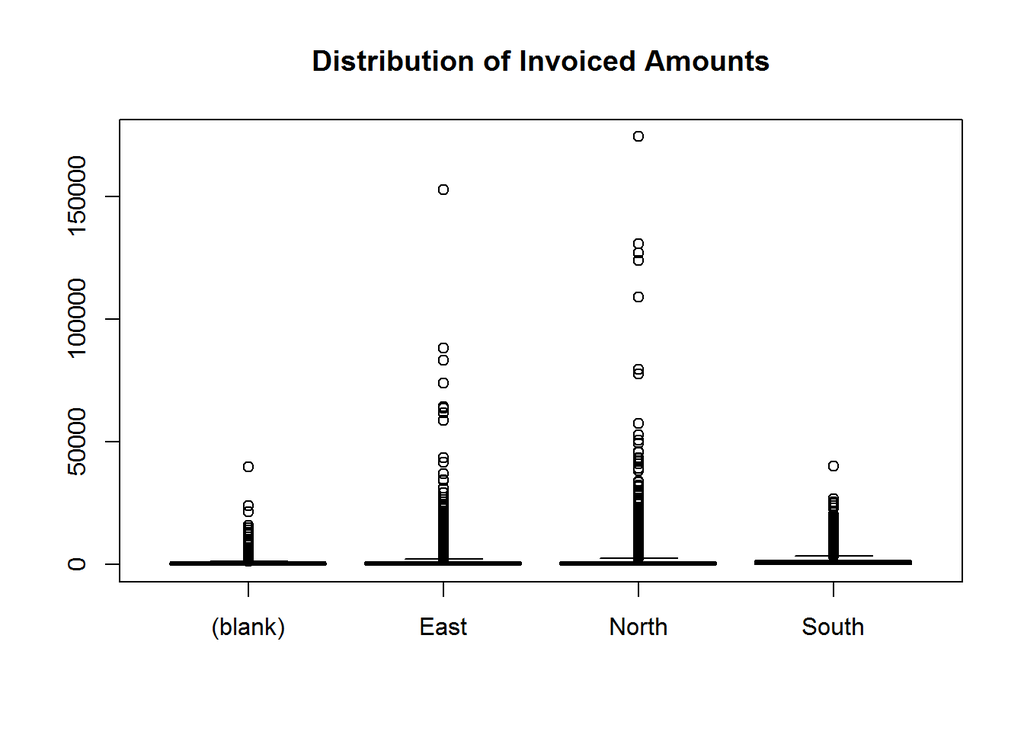

```r
territorydist <- na.omit(territorydist)
boxplot(netivcamt ~ territorycode, territorydist, main="Distribution of Invoiced Amounts")
```

This box plot looks more like a bar chart, but there’s some very interesting information here. The distribution of outliers (any values greater than 1.5x the Interquartile Range above $q3$ or below $q1$) clearly indicates that there are a much greater concentration of large invoiced amounts in the North and East Territories. The South territory is more aligned with out-of-territory sales.

Removing outliers: Since this is such a skewed distribution, removing the outliers and analyzing the bulk of the data is preferable. Typically, we would define outliers as above, however here we have an even more extreme case and should consider that most of our values (transactions) fall between 0 and 2000 dollars.

```r
bpRule <- function(x, const=1.5, positions=FALSE) {
 x <- x[!is.na(x)]
 qs <- quantile(x,probs = c(0.25,0.75))
 iqr <- qs[2]-qs[1]
 if (!positions) x[x < qs[1]-const*iqr | x > qs[2]+const*iqr]
 else which(x < qs[1]-const*iqr | x > qs[2]+const*iqr)
 }
bpRule(territorydist$standardized)
```

[output not shown]

[output cut: 412 more lines]

```r
## Look at non-normalized variable
##territorystdclean <- bpRule(territorydist$standardized)
territoryIVCclean <- bpRule(territorydist$netivcamt)
```

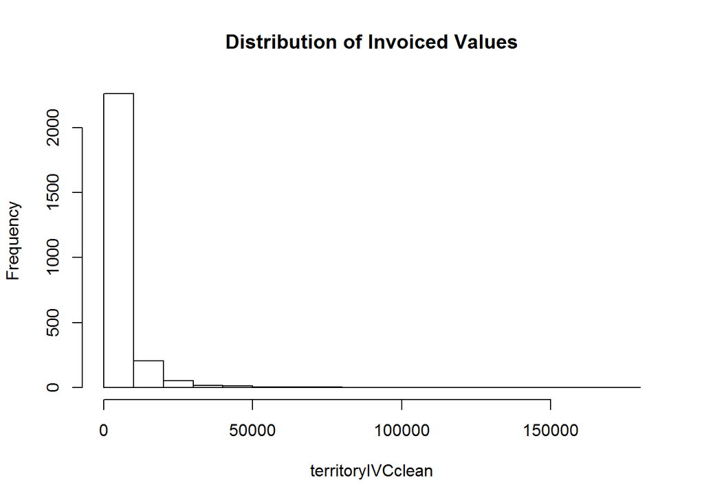

```r
hist(territoryIVCclean, main="Distribution of Invoiced Values")
```

Let’s remove rows that have values greater than $2000. This still leaves us with ~21,000 out of ~24,000 rows of data

```r
subset1k <- subset(territorydist, netivcamt<2000)
subset1k
```

```
## # A tibble: 21,476 x 3
##    territorycode netivcamt standardized
##            <chr>     <dbl>        <dbl>
##  1          East      0.00   -0.3181689
##  2          East      1.00   -0.3178880
##  3          East      1.64   -0.3177083
##  4          East      1.77   -0.3176718
##  5          East      2.04   -0.3175959
##  6          East      2.10   -0.3175791
##  7          East      2.16   -0.3175622
##  8          East      2.40   -0.3174948
##  9          East      2.61   -0.3174359
## 10          East      2.67   -0.3174190
## # ... with 21,466 more rows
```

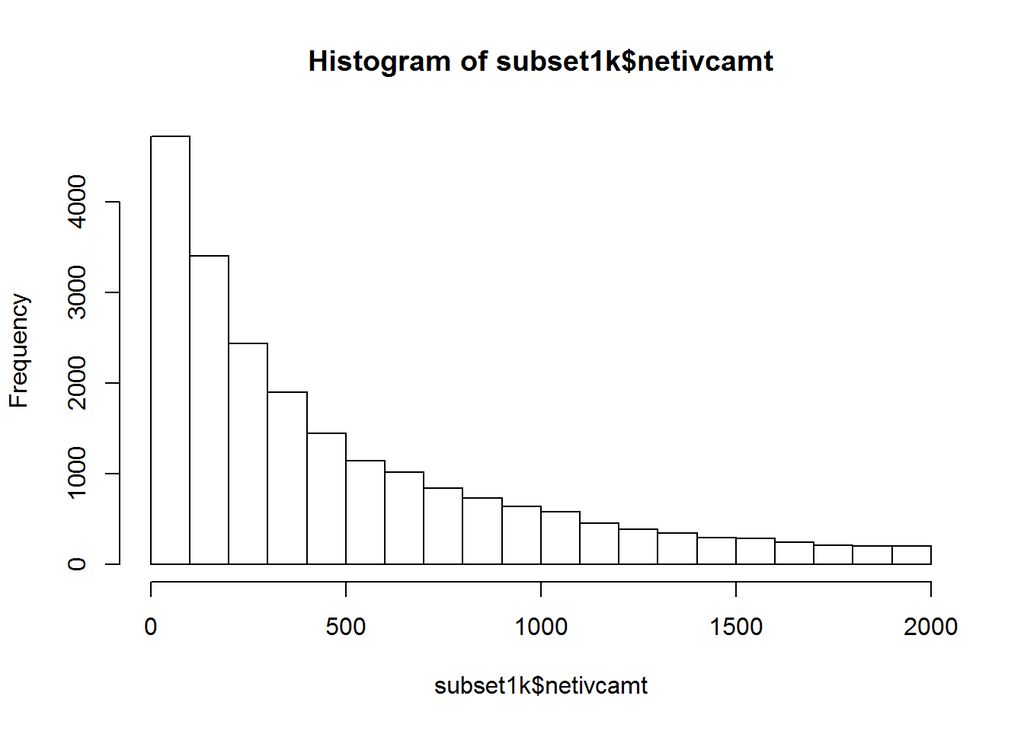

```r
hist(subset1k$netivcamt)
```

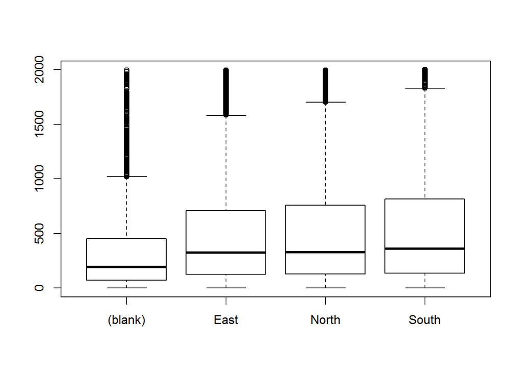

```r
boxplot(subset1k$netivcamt ~ territorycode,subset1k)
```